# HW4_Hedawoo_Rakshanda

## Name: Rakshanda Hedawoo

## Course: BUDT704

## Section: MB11

## Date: 20th October 2023

# Inc 5000 Analysis

Inc 5000 (https://www.inc.com/inc5000) is a respected organization that annually compiles lists of high-growth companies.  
The data file contains information about companies that were included in the Inc. 5000 list for the year 2018. These companies were ranked based on their percentage revenue growth from 2014 to 2017. To be eligible for inclusion, these companies needed to meet specific criteria:

- They must have been established and generating revenue by March 31, 2014.
- They must be privately held, for-profit entities based in the United States.
- They should operate independently, not as subsidiaries or divisions of other companies, as of December 31, 2017. (Note that some of the companies on the list may have since gone public or been acquired.)
- The minimum revenue required for 2014 was 100,000 dollars, and the minimum for 2017 was 2 million dollars.
- Growth rates used to rank these companies were calculated with precision to two decimal places. In cases where multiple companies had the same growth rate, those with higher revenue were given a higher ranking.

#### DataSet Structure: inc 5000 company data

1. **Url (string)** : Url link of inc 5000 website for each company located on inc 5000
2. **Rank (int)** : Rank of the company according to the growth rate
3. **City (string)** : City in which the company is located
4. **Growth (decimal)** : Growth rate of the company
5. **Employees (int)** : Number of employees in the company
6. **Company Name (string)** : Company's name
7. **Website (string)** : link for company's website
8. **City.1 (string)** : State in which the company is located
9. **State (string)** : State Code of the state in which the company is located
10. **Revenuw (decimal)** : Revenue generated by the company
11. **Zip Code (string)** : Zip code of the place where the company is located
12. **Founded (int)** : Founding year of the company
13. **Industry (string)** : Different industry to which the company belongs
14. **City,State (string)** : City and State in which the company is located

```python
#Importing data analysis and visualization libraries
import numpy as np
import pandas as pd
import seaborn as sns
import matplotlib.pyplot as plt
```

# Exploring Inc 5000 Data

In this analysis, we will be majorly using pandas functions for carrying out the different tasks in data analysis.  
Firstly, let's have a look at the 'inc5000-2018' data; we have chose to make RANK column as the index for the data, this will help us view the companies according to the INC ranking which is based on the growth rate of the company.

```python
#Loading data from excel file for analysis
inc_df = pd.read_excel('HW4_inc5000-2018.xlsx',index_col = 1 , skiprows = 0)
inc_df.head()
```

| RANK | URL | CITY | GROWTH | EMPLOYEES | COMPANY NAME | WEBSITE | CITY.1 | STATE | REVENUW | ZIP CODE | FOUNDED | INDUSTRY | CITY, STATE | Unnamed: 14 | Unnamed: 15 |
| --- | --- | --- | --- | --- | --- | --- | --- | --- | --- | --- | --- | --- | --- | --- | --- |
| 1 | https://www.inc.com/profile/swanleap | Madison | 75660.8425 | 49 | SwanLeap | http://swanleap.com | Wisconsin | WI | 98965631 | 53719 | 2013.0 | Logistics & Transportation | Madison, WI | Makes software for the logistics industry that... | During stints as a freight broker and shipping... |
| 2 | https://www.inc.com/profile/popsockets | Boulder | 71423.7620 | 118 | PopSockets | http://popsockets.com | Colorado | CO | 168837562 | 80301 | 2010.0 | Consumer Products & Services | Boulder, CO | Makes self-adhesive, collapsible, expandable c... | Frustrated with his iPhone headphones getting ... |
| 3 | https://www.inc.com/profile/home-chef | Chicago | 60165.5058 | 865 | Home Chef | homechef.com | Illinois | IL | 255047839 | 60611 | 2013.0 | Food & Beverage | Chicago-Naperville-Elgin, IL-IN-WI | NaN | NaN |
| 4 | https://www.inc.com/profile/velocity-global | Denver | 39816.5093 | 55 | Velocity Global | http://velocityglobal.com | Colorado | CO | 49175942 | 80205 | 2013.0 | Business Products & Services | Denver-Aurora-Lakewood, CO | NaN | NaN |
| 5 | https://www.inc.com/profile/depcom-power | Scottsdale | 38962.9022 | 104 | DEPCOM Power | depcompower.com | Arizona | AZ | 219574136 | 85258 | 2013.0 | Energy | Phoenix-Mesa-Scottsdale, AZ | NaN | NaN |

- Logistics & Transportation
- Consumer Product & Services
- Food & Beverages
- Business Products & Services
- Energy
- Computer Hardware
- HR
- Health
- Government Services
- Real Estate

From this data we can know that the growth rate in the above industry sectors is high. This means, that if a fresher/student is looking for a sector to work in, these above sectors are the one they can consider to work for as their growth rate is high.

```python
print('Total companies on the website for the year 2018:',inc_df['COMPANY NAME'].count())
```

```
Total companies on the website for the year 2018: 5000
```

```python
print('Top 25 companies on the INC 5000 list:')
inc_df.iloc[:25,:]
```

```
Top 25 companies on the INC 5000 list:
```

| RANK | URL | CITY | GROWTH | EMPLOYEES | COMPANY NAME | WEBSITE | CITY.1 | STATE | REVENUW | ZIP CODE | FOUNDED | INDUSTRY | CITY, STATE | Unnamed: 14 | Unnamed: 15 |
| --- | --- | --- | --- | --- | --- | --- | --- | --- | --- | --- | --- | --- | --- | --- | --- |
| 1 | https://www.inc.com/profile/swanleap | Madison | 75660.8425 | 49 | SwanLeap | http://swanleap.com | Wisconsin | WI | 98965631 | 53719 | 2013.0 | Logistics & Transportation | Madison, WI | Makes software for the logistics industry that... | During stints as a freight broker and shipping... |
| 2 | https://www.inc.com/profile/popsockets | Boulder | 71423.7620 | 118 | PopSockets | http://popsockets.com | Colorado | CO | 168837562 | 80301 | 2010.0 | Consumer Products & Services | Boulder, CO | Makes self-adhesive, collapsible, expandable c... | Frustrated with his iPhone headphones getting ... |
| 3 | https://www.inc.com/profile/home-chef | Chicago | 60165.5058 | 865 | Home Chef | homechef.com | Illinois | IL | 255047839 | 60611 | 2013.0 | Food & Beverage | Chicago-Naperville-Elgin, IL-IN-WI | NaN | NaN |
| 4 | https://www.inc.com/profile/velocity-global | Denver | 39816.5093 | 55 | Velocity Global | http://velocityglobal.com | Colorado | CO | 49175942 | 80205 | 2013.0 | Business Products & Services | Denver-Aurora-Lakewood, CO | NaN | NaN |
| 5 | https://www.inc.com/profile/depcom-power | Scottsdale | 38962.9022 | 104 | DEPCOM Power | depcompower.com | Arizona | AZ | 219574136 | 85258 | 2013.0 | Energy | Phoenix-Mesa-Scottsdale, AZ | NaN | NaN |
| 6 | https://www.inc.com/profile/aeronux-airways | Marietta | 20005.2390 | 17 | Aeronux Airways | aeronux.com | Georgia | GA | 21874500 | 30066 | 2011.0 | Logistics & Transportation | Atlanta-Sandy Springs-Roswell, GA | NaN | NaN |
| 7 | https://www.inc.com/profile/diamond-assets | Milton | 19717.5129 | 41 | Diamond Assets | diamond-assets.com | Wisconsin | WI | 43084462 | 53563 | 2014.0 | Computer Hardware | Janesville, WI | NaN | NaN |
| 8 | https://www.inc.com/profile/gforce-life-sciences | Chicago | 16426.6575 | 13 | GForce Life Sciences | http://gforcestaff.com | Illinois | IL | 16893384 | 60606 | 2013.0 | Human Resources | Chicago-Naperville-Elgin, IL-IN-WI | NaN | NaN |
| 8 | https://www.inc.com/profile/flexport | San Francisco | 15911.2237 | 532 | Flexport | http://flexport.com | California | CA | 224745864 | 94102 | 2013.0 | Logistics & Transportation | San Francisco-Oakland-Hayward, CA | NaN | NaN |
| 9 | https://www.inc.com/profile/scientistcom | Solana Beach | 15267.7557 | 49 | Scientist.com | http://scientist.com | California | CA | 50268390 | 92075 | 2007.0 | Health | San Diego-Carlsbad, CA | NaN | NaN |
| 10 | https://www.inc.com/profile/the-garrett-companies | Greenwood | 14821.8995 | 40 | The Garrett Companies | http://thegarrettco.com | Indiana | IN | 82070447 | 46143 | 2014.0 | Real Estate | Indianapolis-Carmel-Anderson, IN | NaN | NaN |
| 11 | https://www.inc.com/profile/dgc-international | Vienna | 14475.5148 | 55 | DGC International | dgci.com | Virginia | VA | 179707790 | 22182 | 2010.0 | Government Services | Washington-Arlington-Alexandria, DC-VA-MD-WV | NaN | NaN |
| 12 | https://www.inc.com/profile/exabeam | San Mateo | 14032.4773 | 153 | Exabeam | exabeam.com | California | CA | 18781497 | 94403 | 2013.0 | Security | San Francisco-Oakland-Hayward, CA | NaN | NaN |
| 13 | https://www.inc.com/profile/podium | Lehi | 13645.2287 | 254 | Podium | podium.com | Utah | UT | 30248850 | 84043 | 2013.0 | Business Products & Services | Provo-Orem, UT | NaN | NaN |
| 14 | https://www.inc.com/profile/inova-us | Key Biscayne | 13135.1845 | 25 | Inova US | inovaus.com | Florida | FL | 39445482 | 33149 | 2008.0 | Advertising & Marketing | Miami-Fort Lauderdale-West Palm Beach, FL | NaN | NaN |
| 15 | https://www.inc.com/profile/adrizer | Sarasota | 12500.7218 | 24 | AdRizer | adrizer.com | Florida | FL | 16723552 | 34236 | 2013.0 | Software | Sarasota-Bradenton-Venice, FL | NaN | NaN |
| 16 | https://www.inc.com/profile/welfont | Tampa | 11359.3104 | 55 | Welfont | welfont.com | Florida | FL | 14055761 | 33602 | 2014.0 | Real Estate | Tampa-St. Petersburg-Clearwater, FL | NaN | NaN |
| 17 | https://www.inc.com/profile/thinx | New York City | 10924.1379 | 44 | THINX | shethinx.com | New York | NY | 39556922 | 10001 | 2014.0 | Retail | New York-Newark-Jersey City, NY-NJ-PA | NaN | NaN |
| 18 | https://www.inc.com/profile/draken-international | Lakeland | 10562.3592 | 200 | Draken International | drakenintl.com | Florida | FL | 30403184 | 33811 | 2011.0 | Government Services | Lakeland, FL | NaN | NaN |
| 19 | https://www.inc.com/profile/calmcom | San Francisco | 10548.7682 | 25 | Calm.com | calm.com | California | CA | 22347505 | 94105 | 2012.0 | Consumer Products & Services | San Francisco-Oakland-Hayward, CA | NaN | NaN |
| 20 | https://www.inc.com/profile/curate-partners | Stoneham | 10056.5729 | 13 | Curate Partners | curatepartners.com | Massachusetts | MA | 12328556 | 2180 | 2014.0 | Human Resources | Boston-Cambridge-Newton, MA-NH | NaN | NaN |
| 21 | https://www.inc.com/profile/figs | Los Angeles | 9947.5655 | 45 | FIGS | wearfigs.com | California | CA | 23115831 | 90064 | 2013.0 | Retail | Los Angeles-Long Beach-Anaheim, CA | NaN | NaN |
| 22 | https://www.inc.com/profile/techanax | Woodbridge | 9508.0119 | 20 | TechAnax | techanax.com | Virginia | VA | 24498797 | 22193 | 2012.0 | Government Services | Washington-Arlington-Alexandria, DC-VA-MD-WV | NaN | NaN |
| 24 | https://www.inc.com/profile/snacknation | Culver City | 9199.5777 | 158 | SnackNation | snacknation.com | California | CA | 16890172 | 90232 | 2014.0 | Food & Beverage | Los Angeles-Long Beach-Anaheim, CA | NaN | NaN |
| 25 | https://www.inc.com/profile/brooklinen | Brooklyn | 9154.1993 | 22 | Brooklinen | brooklinen.com | New York | NY | 47864847 | 11201 | 2014.0 | Retail | New York-Newark-Jersey City, NY-NJ-PA | NaN | NaN |

# Data Cleaning

Before we start analysing the above data, let us see if the data needs some cleaning to do.  
Oh! there are some irregularities in the data that we must handle that are:

## Handling duplicates:

- In the data frame we can see that in the index, two companies have the same rank even though their growth rate is significantly different.
- Therefore, to handle this duplicate rank we will correct the ranks below 8. As, there was just one duplicate data it will be possible for me to correct it, however if their where multiple duplicates I would have to use some other column as the index for the data.

```python
#finding the duplicate
inc_df.reset_index(inplace = True)
inc_df.duplicated(subset='RANK').head(10)
```

```
0    False
1    False
2    False
3    False
4    False
5    False
6    False
7    False
8     True
9    False
dtype: bool
```

```python
#Fixing the duplicate by correcting the rank
inc_df['RANK'] = np.arange(1, len(inc_df) + 1)
inc_df.set_index('RANK',inplace=True)
inc_df.head()
```

| RANK | URL | CITY | GROWTH | EMPLOYEES | COMPANY NAME | WEBSITE | CITY.1 | STATE | REVENUW | ZIP CODE | FOUNDED | INDUSTRY | CITY, STATE | Unnamed: 14 | Unnamed: 15 |
| --- | --- | --- | --- | --- | --- | --- | --- | --- | --- | --- | --- | --- | --- | --- | --- |
| 1 | https://www.inc.com/profile/swanleap | Madison | 75660.8425 | 49 | SwanLeap | http://swanleap.com | Wisconsin | WI | 98965631 | 53719 | 2013.0 | Logistics & Transportation | Madison, WI | Makes software for the logistics industry that... | During stints as a freight broker and shipping... |
| 2 | https://www.inc.com/profile/popsockets | Boulder | 71423.7620 | 118 | PopSockets | http://popsockets.com | Colorado | CO | 168837562 | 80301 | 2010.0 | Consumer Products & Services | Boulder, CO | Makes self-adhesive, collapsible, expandable c... | Frustrated with his iPhone headphones getting ... |
| 3 | https://www.inc.com/profile/home-chef | Chicago | 60165.5058 | 865 | Home Chef | homechef.com | Illinois | IL | 255047839 | 60611 | 2013.0 | Food & Beverage | Chicago-Naperville-Elgin, IL-IN-WI | NaN | NaN |
| 4 | https://www.inc.com/profile/velocity-global | Denver | 39816.5093 | 55 | Velocity Global | http://velocityglobal.com | Colorado | CO | 49175942 | 80205 | 2013.0 | Business Products & Services | Denver-Aurora-Lakewood, CO | NaN | NaN |
| 5 | https://www.inc.com/profile/depcom-power | Scottsdale | 38962.9022 | 104 | DEPCOM Power | depcompower.com | Arizona | AZ | 219574136 | 85258 | 2013.0 | Energy | Phoenix-Mesa-Scottsdale, AZ | NaN | NaN |

## Data Transformation- Renaming and Deleting some columns:

- Next, we can clearly see that some columns are misspelled for example 'REVENEW',
- Secondly, we have a duplicate column name as CITY.1 which in fact is not a city name but a state name.
- Thirdly, we have some unnamed columns that have values only for the first 2 rows and rest of them are missing.
- So in order to proceed with the analysis we will first, rename the column names correctly, then change the 'CITY.1' column into 'STATE' and 'STATE' into 'STATE CODE', and delete the last two columns as they do not seem very useful for doing further analysis.

Hence, the the final dataset should look like this:

```python
#renaming columns for better understanding
inc_df.rename(columns={'CITY.1':'State','STATE':'State Code','REVENUW':'Revenue','EMPLOYEES':'Employee Count','CITY':'City'
                      ,'GROWTH':'Growth','COMPANY NAME':'Company Name','WEBSITE':'Website','ZIP CODE':'Zip Code',
                       'FOUNDED':'Founding Year','INDUSTRY':'Industry','URL':'Url',},inplace = True)
#removing unwanted columns
inc_df.drop(['CITY, STATE','Unnamed: 14','Unnamed: 15'],axis=1,inplace=True)
inc_df.head()
```

| RANK | Url | City | Growth | Employee Count | Company Name | Website | State | State Code | Revenue | Zip Code | Founding Year | Industry |
| --- | --- | --- | --- | --- | --- | --- | --- | --- | --- | --- | --- | --- |
| 1 | https://www.inc.com/profile/swanleap | Madison | 75660.8425 | 49 | SwanLeap | http://swanleap.com | Wisconsin | WI | 98965631 | 53719 | 2013.0 | Logistics & Transportation |
| 2 | https://www.inc.com/profile/popsockets | Boulder | 71423.7620 | 118 | PopSockets | http://popsockets.com | Colorado | CO | 168837562 | 80301 | 2010.0 | Consumer Products & Services |
| 3 | https://www.inc.com/profile/home-chef | Chicago | 60165.5058 | 865 | Home Chef | homechef.com | Illinois | IL | 255047839 | 60611 | 2013.0 | Food & Beverage |
| 4 | https://www.inc.com/profile/velocity-global | Denver | 39816.5093 | 55 | Velocity Global | http://velocityglobal.com | Colorado | CO | 49175942 | 80205 | 2013.0 | Business Products & Services |
| 5 | https://www.inc.com/profile/depcom-power | Scottsdale | 38962.9022 | 104 | DEPCOM Power | depcompower.com | Arizona | AZ | 219574136 | 85258 | 2013.0 | Energy |

# More Data for INC 5000 companies based on Geography

Phew! now that cleaning is done, we will see if we can get some more geographic data on the companies. However, except the state and the city no geographic information is present in our previous dataset.  
For analysing this we have another data set called as 'states_by_region'. This data gives us information about which state is in which region of the United States and it is further divided into divisions.

### DataSet Structure: states by region data

1. **State (string)** : State full name
2. **State Code (string)** : State Code
3. **Region (string)** : Region in which state is located
4. **Division (string)** : Geographical division where the region is located

### Let's have a look at the Region data:

We can see that the states are divided into 4 Regions and 9 Divisions with are:

#### Regions:

1. Midwest
2. Northeast
3. South
4. West

#### Divisions:

1. Pacific
2. Mountain
3. New England
4. South Atlantic
5. Middle Atlantic
6. East South Central
7. West South Central
8. West North Central
9. East North Central

```python
#Loading data from csv file for analysis
region_df = pd.read_csv('HW4_states_by_region.csv',delimiter=',',skiprows=0)
region_df.head()
```

|  | State | State Code | Region | Division |
| --- | --- | --- | --- | --- |
| 0 | Alaska | AK | West | Pacific |
| 1 | Alabama | AL | South | East South Central |
| 2 | Arkansas | AR | South | West South Central |
| 3 | Arizona | AZ | West | Mountain |
| 4 | California | CA | West | Pacific |

## Merging INC 5000 and Region Datasets

Now that we have our region dataset loaded for carrying out further analysis we need to merge the INC 5000 and the Region dataset in order to ease the process of analysis.  
We will do that on the basis of **State Code**. This is the only common column between the two dataset on which we can join them.  
After performing the join our dataset should look something like this:

```python
#Connecting both the dataset to make one dataset for easier analysis
merged_df = pd.merge(inc_df,region_df,on='State Code',how='inner',left_on=None, right_on=None,suffixes=('','_new'))
inc_df['Region'] = merged_df['Region']
inc_df.head()
```

| RANK | Url | City | Growth | Employee Count | Company Name | Website | State | State Code | Revenue | Zip Code | Founding Year | Industry | Region |
| --- | --- | --- | --- | --- | --- | --- | --- | --- | --- | --- | --- | --- | --- |
| 1 | https://www.inc.com/profile/swanleap | Madison | 75660.8425 | 49 | SwanLeap | http://swanleap.com | Wisconsin | WI | 98965631 | 53719 | 2013.0 | Logistics & Transportation | Midwest |
| 2 | https://www.inc.com/profile/popsockets | Boulder | 71423.7620 | 118 | PopSockets | http://popsockets.com | Colorado | CO | 168837562 | 80301 | 2010.0 | Consumer Products & Services | Midwest |
| 3 | https://www.inc.com/profile/home-chef | Chicago | 60165.5058 | 865 | Home Chef | homechef.com | Illinois | IL | 255047839 | 60611 | 2013.0 | Food & Beverage | Midwest |
| 4 | https://www.inc.com/profile/velocity-global | Denver | 39816.5093 | 55 | Velocity Global | http://velocityglobal.com | Colorado | CO | 49175942 | 80205 | 2013.0 | Business Products & Services | Midwest |
| 5 | https://www.inc.com/profile/depcom-power | Scottsdale | 38962.9022 | 104 | DEPCOM Power | depcompower.com | Arizona | AZ | 219574136 | 85258 | 2013.0 | Energy | Midwest |

# Statistical Measures

```python
#Descriptive statistics
revenue_std_deviation = inc_df['Revenue'].std()
mean_revenue = inc_df['Revenue'].mean()

print('Minimum revenue',inc_df['Revenue'].min())
print('Maximum revenue',inc_df['Revenue'].max())
print(f'Mean revenue {mean_revenue:.2f}')
print('Median revenue',inc_df['Revenue'].median())
print(f'Standard deviation of revenue {revenue_std_deviation:.2f}')
```

```
Minimum revenue 1952209
Maximum revenue 16433210000
Mean revenue 41221263.20
Median revenue 9575009.5
Standard deviation of revenue 282990264.70
```

```python
threshold_value = 500_00_000
threshold_year = 2015

company_founded_before2015 = inc_df[(inc_df['Founding Year']<2015) & (inc_df['Revenue']>=threshold_value)]
company_revenue_above50 = (company_founded_before2015['Revenue'].count()/inc_df['Revenue'].count())*100
print(f'{company_revenue_above50:.2f} % of companies founded prior to 2015 have achieved revenue of at least $50 million')
```

```
13.62 % of companies founded prior to 2015 have achieved revenue of at least $50 million
```

# Analysing INC 5000 companies

Now that we have an overall idea about how the revenue data is distributed for different companies, let us analyse further according to different columns in the data.  
Instead of filtering the data again and again according to the different conditions, we can create a function that does the filtering work for us. The below function, returns us the result on basis of our query for a column and its value.

### Let us see some examples of using a custom-made filtering function:

```python
# we should list at least 20 rows
pd.set_option('min_rows',20)

# get's data based on a particular column name and a value for analysing column-wise data
def display_data(dataframe,number_of_rows=10,Category='None',value='None'):
    query_result = dataframe.sort_values(by='Revenue',ascending=False)
    if(Category!='None' and value!='None'):
        query_result = query_result[query_result[Category]==value]
    else:
        return query_result.iloc[:number_of_rows,:]
    return query_result.iloc[:number_of_rows,:]
```

#### Analysing INC 5000 overall top companies

Let's look at a overall company view. With the help of the above custom filtering function, let's find out the top 15 companies based on the revenue.

- **Prime Therapeutics** generates the highest revenue and belongs to the Health sector.
- **Allied Universal** even though having the largest number of employee, they are generating the second most highest revenue overall.
- Lastly, **ARMADA** have the lowest employee force among the top 15 companies.

```python
print('Top 15 companies:')
display_data(inc_df,15)
```

```
Top 15 companies:
```

| RANK | Url | City | Growth | Employee Count | Company Name | Website | State | State Code | Revenue | Zip Code | Founding Year | Industry | Region |
| --- | --- | --- | --- | --- | --- | --- | --- | --- | --- | --- | --- | --- | --- |
| 1288 | https://www.inc.com/profile/prime-therapeutics | Eagan | 372.1123 | 4329 | Prime Therapeutics | primetherapeutics.com | Minnesota | MN | 16433210000 | 55121 | 1998.0 | Health | West |
| 1318 | https://www.inc.com/profile/allied-universal | Santa Ana | 363.0638 | 150000 | Allied Universal | aus.com | California | CA | 5301534000 | 92705 | 1965.0 | Security | West |
| 4226 | https://www.inc.com/profile/carahsoft-technology | Reston | 80.4559 | 900 | Carahsoft Technology | carahsoft.com | Virginia | VA | 4107537719 | 20190 | 2004.0 | Government Services | Midwest |
| 3439 | https://www.inc.com/profile/endeavor | Beverly Hills | 110.9724 | 6200 | Endeavor | endeavorco.com | New York | NY | 3541178000 | 90210 | 1995.0 | Media | Northeast |
| 4341 | https://www.inc.com/profile/drivetime | Tempe | 76.6689 | 6111 | DriveTime | drivetime.com | Arizona | AZ | 3267077000 | 85281 | 2002.0 | Consumer Products & Services | South |
| 4204 | https://www.inc.com/profile/armada | Pittsburgh | 81.1360 | 468 | ARMADA | armada.net | Pennsylvania | PA | 2950772000 | 15238 | 1890.0 | Logistics & Transportation | Midwest |
| 3546 | https://www.inc.com/profile/srs-distribution | McKinney | 106.2021 | 3132 | SRS Distribution | srsdistribution.com | Texas | TX | 2183778171 | 75070 | 2008.0 | Consumer Products & Services | Northeast |
| 2064 | https://www.inc.com/profile/pinnacle-group | Dallas | 216.2477 | 1563 | Pinnacle Group | pinnacle1.com | Texas | TX | 2110176184 | 75240 | 1996.0 | Human Resources | South |
| 4973 | https://www.inc.com/profile/insight-global | Atlanta | 58.1746 | 2570 | Insight Global | insightglobal.com | Georgia | GA | 1928758851 | 30319 | 2001.0 | Business Products & Services | Northeast |
| 3010 | https://www.inc.com/profile/transportation-ins... | Hickory | 134.1974 | 510 | Transportation Insight | transportationinsight.com | North Carolina | NC | 1892660132 | 28602 | 1999.0 | Logistics & Transportation | Midwest |
| 1388 | https://www.inc.com/profile/victra | Raleigh | 341.3350 | 6000 | VICTRA | victra.com | North Carolina | NC | 1460373019 | 27615 | 1996.0 | Retail | West |
| 3496 | https://www.inc.com/profile/strike | The Woodlands | 107.8916 | 5939 | Strike | strikeusa.com | Texas | TX | 1401259860 | 77380 | 2003.0 | Energy | Northeast |
| 4551 | https://www.inc.com/profile/avella-specialty-p... | Phoenix | 71.2137 | 706 | Avella Specialty Pharmacy | avella.com | Arizona | AZ | 1351981297 | 85085 | 1996.0 | Health | South |
| 2110 | https://www.inc.com/profile/jeunesse-global | Lake Mary | 210.2303 | 825 | Jeunesse Global | jeunesseglobal.com | Florida | FL | 1300731294 | 32746 | 2009.0 | Consumer Products & Services | South |
| 4987 | https://www.inc.com/profile/pacific-dental-ser... | Irvine | 57.6902 | 9008 | Pacific Dental Services | pacificdentalservices.com | California | CA | 1186683500 | 92614 | 1994.0 | Health | Northeast |

#### Analysing INC 5000 companies based on Industry

Now let's analyse according to the industry.  
For example, let us take Food and Beverage Industry and find out the top 10 companies in the food and beverage industry.

- **Jersey Mike's Sub** is the only company from the South region that is generating the highest revenue across this industry.
- Most of these top 10 companies are originated from the Northeast and West Region.
- Even though **Home Chef** is ranked 3 for its exceptional growth rate, however it is not generating the highest revenue in the Food & Beverage Industry.

```python
print('The top ten companies in the food and beverage industry:')
display_data(inc_df,10,'Industry','Food & Beverage')
```

```
The top ten companies in the food and beverage industry:
```

| RANK | Url | City | Growth | Employee Count | Company Name | Website | State | State Code | Revenue | Zip Code | Founding Year | Industry | Region |
| --- | --- | --- | --- | --- | --- | --- | --- | --- | --- | --- | --- | --- | --- |
| 3757 | https://www.inc.com/profile/jersey-mikes-subs | Manasquan | 97.4898 | 19000 | Jersey Mike's Subs | jerseymikes.com | New Jersey | NJ | 974782877 | 8736 | 1956.0 | Food & Beverage | South |
| 3483 | https://www.inc.com/profile/monogram-foods | Memphis | 108.5890 | 2700 | Monogram Foods | monogramfoods.com | Tennessee | TN | 670665838 | 38117 | 2004.0 | Food & Beverage | Northeast |
| 998 | https://www.inc.com/profile/gps-hospitality | Atlanta | 493.1933 | 11016 | GPS Hospitality | gpshospitality.com | Georgia | GA | 551176689 | 30328 | 2012.0 | Food & Beverage | West |
| 3434 | https://www.inc.com/profile/freddys-frozen-cus... | Wichita | 111.0822 | 11886 | Freddy's Frozen Custard & Steakburgers | freddysusa.com | Kansas | KS | 410993763 | 67206 | 2002.0 | Food & Beverage | Northeast |
| 4061 | https://www.inc.com/profile/blount-fine-foods | Fall River | 86.0419 | 628 | Blount Fine Foods | blountfinefoods.com | Massachusetts | MA | 338254000 | 1760 | 1946.0 | Food & Beverage | West |
| 3 | https://www.inc.com/profile/home-chef | Chicago | 60165.5058 | 865 | Home Chef | homechef.com | Illinois | IL | 255047839 | 60611 | 2013.0 | Food & Beverage | Midwest |
| 3537 | https://www.inc.com/profile/coopers-hawk-winer... | Countryside | 106.4360 | 4155 | Cooper's Hawk Winery & Restaurants | chwinery.com | Illinois | IL | 241827341 | 60525 | 2005.0 | Food & Beverage | Northeast |
| 2436 | https://www.inc.com/profile/nothing-bundt-cakes | Addison | 177.5477 | 230 | Nothing Bundt Cakes | nothingbundtcakes.com | Texas | TX | 220026175 | 75001 | 1997.0 | Food & Beverage | Northeast |
| 515 | https://www.inc.com/profile/mod-pizza | Bellevue | 979.4089 | 5500 | MOD Pizza | modpizza.com | Washington | WA | 219487000 | 98008 | 2008.0 | Food & Beverage | West |
| 4633 | https://www.inc.com/profile/studio-movie-grill | Dallas | 68.3820 | 5800 | Studio Movie Grill | studiomoviegrill.com | Texas | TX | 211683327 | 75251 | 2000.0 | Food & Beverage | Midwest |

#### Analysing INC 5000 companies based on City

Further let's analyse the data City wise.  
For example, lets see what are the top 3 companies in the New York City.

- Sterling Talent Solutions is geographically located to the midwest of the City and is the highest revenue generating company in New York for Business Products & Services Industry.
- Both Compass and Peloton are located towards the west side of the city and were founded in the year 2012. One being in the real estate and another in the Retail sector respectively.

```python
print('The top three companies located in New York City:')
display_data(inc_df,3,'City','New York City')
```

```
The top three companies located in New York City:
```

| RANK | Url | City | Growth | Employee Count | Company Name | Website | State | State Code | Revenue | Zip Code | Founding Year | Industry | Region |
| --- | --- | --- | --- | --- | --- | --- | --- | --- | --- | --- | --- | --- | --- |
| 4855 | https://www.inc.com/profile/sterling-talent-so... | New York City | 61.7196 | 4087 | Sterling Talent Solutions | sterlingtalentsolutions.com | New York | NY | 480956135 | 10004 | 1975.0 | Business Products & Services | Midwest |
| 71 | https://www.inc.com/profile/compass | New York City | 4309.0950 | 464 | Compass | compass.com | New York | NY | 370560142 | 10011 | 2012.0 | Real Estate | West |
| 97 | https://www.inc.com/profile/peloton | New York City | 3710.7823 | 872 | Peloton | onepeloton.com | New York | NY | 328337000 | 10001 | 2012.0 | Retail | West |

#### Analysing INC 5000 companies State-wise

Lastly, on the basis of geography let us analyse the companies state wise.  
For example, let us see the top 5 companies from Maryland.

- INFINITI HR is the tio revenue generating company in Maryland that belongs to the Human Resources industry.
- Out of 5, 3 companies are under Government Services industry that are generating higher revenue as compared to other industry sector.

```python
print('The top five companies in Maryland:')
display_data(inc_df,5,'State','Maryland')
```

```
The top five companies in Maryland:
```

| RANK | Url | City | Growth | Employee Count | Company Name | Website | State | State Code | Revenue | Zip Code | Founding Year | Industry | Region |
| --- | --- | --- | --- | --- | --- | --- | --- | --- | --- | --- | --- | --- | --- |
| 3357 | https://www.inc.com/profile/infiniti-hr | Burtonsville | 115.2400 | 34499 | INFINITI HR | infinitihr.com | Maryland | MD | 371942140 | 20866 | 2008.0 | Human Resources | Northeast |
| 349 | https://www.inc.com/profile/t-rex-solutions | Greenbelt | 1427.5775 | 385 | T-Rex Solutions | trexsolutionsllc.com | Maryland | MD | 195539254 | 20770 | 1999.0 | Government Services | Midwest |
| 3196 | https://www.inc.com/profile/the-maryland-and-d... | Salisbury | 122.8835 | 30 | The Maryland and Delaware Group of Long and Fo... | easternshorehomesolutions.com | Maryland | MD | 106544544 | 21801 | 2014.0 | Real Estate | West |
| 1732 | https://www.inc.com/profile/n2grate | Greenbelt | 263.3315 | 44 | n2grate | n2grate.com | Maryland | MD | 101674761 | 20770 | 2010.0 | Government Services | South |
| 2077 | https://www.inc.com/profile/tista-science-and-... | Rockville | 214.2944 | 296 | TISTA Science and Technology | tistatech.com | Maryland | MD | 95475617 | 20854 | 2005.0 | Government Services | South |

# Awards Distribution

### Let us have a look at which companies got Trailblazers and which of them received Pioneer award

```python
#Filtering companies by Service industry
service_based_company = inc_df[inc_df['Industry'].str.contains('Services')].sort_values(by='Revenue',ascending=False)
service_based_company.reset_index(inplace=True)

# additional Award column
service_based_company['Awards']='No Award'

# top quarter company count
top_quarter_count = int(service_based_company['Company Name'].count()*25/100)
# top half company count
top_half_count = int(service_based_company['Company Name'].count()*50/100)

# Trailblazer award to top quarter companies
service_based_company.loc[:top_quarter_count-1,'Awards'] = 'Trailblazer'

# Pioneer award to companies in top 50 but not in top 25
service_based_company.loc[top_quarter_count:top_half_count-1,'Awards'] = 'Pioneer'

service_based_company.loc[service_based_company['Awards']!='No Award',('Company Name','RANK','Revenue','Awards')]
```

|  | Company Name | RANK | Revenue | Awards |
| --- | --- | --- | --- | --- |
| 0 | Carahsoft Technology | 4226 | 4107537719 | Trailblazer |
| 1 | DriveTime | 4341 | 3267077000 | Trailblazer |
| 2 | SRS Distribution | 3546 | 2183778171 | Trailblazer |
| 3 | Insight Global | 4973 | 1928758851 | Trailblazer |
| 4 | Jeunesse Global | 2110 | 1300731294 | Trailblazer |
| 5 | Freedom Mortgage | 2716 | 1154661039 | Trailblazer |
| 6 | United Shore | 2158 | 1085837000 | Trailblazer |
| 7 | Readerlink | 4141 | 1051402000 | Trailblazer |
| 8 | Epiq | 1866 | 1007138000 | Trailblazer |
| 9 | Georgetown Mortgage | 3868 | 884193608 | Trailblazer |
| ... | ... | ... | ... | ... |
| 629 | Semihandmade | 1300 | 9637413 | Pioneer |
| 630 | Imacuclean | 3572 | 9624183 | Pioneer |
| 631 | Fort Collins Heating and Air Conditoning | 3728 | 9610953 | Pioneer |
| 632 | Innovative Commercial Environments | 4745 | 9598833 | Pioneer |
| 633 | City Wide Maintenance of Kansas | 3466 | 9575064 | Pioneer |
| 634 | Rastaclat | 2551 | 9544805 | Pioneer |
| 635 | 2M Research | 285 | 9540000 | Pioneer |
| 636 | Language on Demand | 1302 | 9529200 | Pioneer |
| 637 | Next Day Dumpsters | 4330 | 9504000 | Pioneer |
| 638 | Full Circle Home | 1436 | 9492423 | Pioneer |

639 rows × 4 columns

# Visualizing Data Region-wise

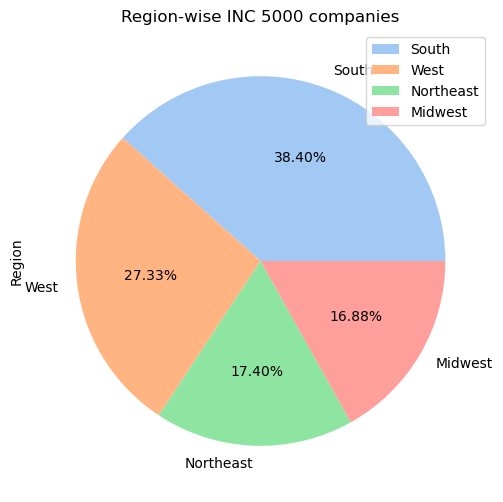

```python
inc_states_df = inc_df['Region'].value_counts().to_frame()

#plotting the pie chart
colors = sns.color_palette('pastel')[0:5]
inc_states_df.plot(kind='pie', y='Region', figsize=(10, 6), colors=colors,autopct='%.2f%%')
plt.title('Region-wise INC 5000 companies')
plt.show()
```

## Inference

1. It is evident that South region has 38.40% of the total INC 5000 companies, that is the highest number of companies listed on the INC 5000 website. This might be the case because the companies originating in this region are all well-established firms; generating high revenue as compared to the other companies in the same industry.
2. Secondly, as West region of the United States comprises of 27.33% of all companies entailing mostly tech and start ups. Due to which it has ranked second in the list of INC 5000 companies.
3. Finally, Northeast and Midwest has approximately similar proportion of companies registered as INC 5000 companies.

"I pledge on my honor that I have not given nor received any unauthorized assistance on this assignment."  
--Rakshanda Hedawoo.